# Analysis and quantification of mass spectrometry imaging data

Dr Matt Smith

31 July, 2024

# 1. Load packages

```r
library(quantMSImageR)
library(Cardinal)
library(dplyr)
library(tibble)
library(tidyr)
library(chemCal)
library(ggplot2)
library(ggpmisc)
library(viridis)
library(DT)
```

# 2. Set paths and filenames

```r
data_path = system.file('extdata', package = 'quantMSImageR') # Path to test data
#data_path = "C:/Users/matsmi/OneDrive - Karolinska Institutet/Dokument/MSI/quantMSImageR/data"

# Set filenames
ion_lib_fn = sprintf("%s/ion_library.txt", data_path)
#ion_lib_fn = "C:/Users/matsmi/OneDrive - Karolinska Institutet/Dokument/MSI/quantMSImageR/data/ion_library.txt"

tissue_fn = "tissue_MRM_data"
cal_fn = "cal_MRM_data"


sample_meta_fn =  sprintf("%s/sample_metadata.csv", data_path)
cal_meta_fn = sprintf("%s/calibration_metadata.csv", data_path)

cal_roi_fn = sprintf("%s/%s.raw/cal_ROIs.csv", data_path, cal_fn)
tissue_pixels_fn = sprintf("%s/%s.raw/tissue_ROIs.csv", data_path, tissue_fn)
tissue_anat_fn = sprintf("%s/%s.raw/anat_ROIs.csv", data_path, tissue_fn)
```

# 3. Load files

## 3.1 Metadata files

```r
sample_metadata = read.csv(sample_meta_fn)

cal_metadata = read.csv(cal_meta_fn)
# cal_metadata requires 'identifier' header which matches the labels from the calibration sample

cal_roi_df = read.csv(cal_roi_fn)
tissue_pixels_df = read.csv(tissue_pixels_fn)
tissue_anat_ROIs = read.csv(tissue_anat_fn)
```

## 3.2 DESI-MRM data files

Read MRM mass spectrometry imaging data files into R, using the auto-generated Analyte 1.txt file.

```r
tissue = read_mrm(name = tissue_fn, folder = data_path, lib_ion_path = ion_lib_fn)

# Read calibration mix MRM files
cal_mix =  read_mrm(name = cal_fn, folder = data_path, lib_ion_path = ion_lib_fn)
```

## 3.3 Set common m/z axis

Set a common feature data axis for each data file, to enable merging of the data downstream. In this example the calibration data is used as reference.

```r
tissue = setCommonAxis(MSIobjects = list(tissue, cal_mix), ref_fdata = fData(cal_mix))[[1]]

# Tissue feature data
DT::datatable(data.frame(fData(tissue)), width = '75%')
```

|  | mz | analyte | precursor_mz | product_mz | name |
| --- | --- | --- | --- | --- | --- |
| 1 | 1 | Analyte | 313.2 | 183.1 | 12_13-DiHOME |

```r
# Calibration miz feature data
DT::datatable(data.frame(fData(cal_mix)), width = '75%')
```

|  | mz | analyte | precursor_mz | product_mz | name |
| --- | --- | --- | --- | --- | --- |
| 1 | 1 | Analyte | 313.2 | 183.1 | 12_13-DiHOME |

# 4. Select calibration spikes from calibration DESI-MRM data

For each spot select a region of interest (ROI) around the entire area, such that the amount of standard can be divided by number of pixels to determine the average amount per pixel. If standard addition approach to be used, create an additional ROI on the surface away form the calibration spikes.

## 4.1 Manually select ROIs (example)

The ROIs can be generated using the Cardinal::selectROI() tool as shown here:

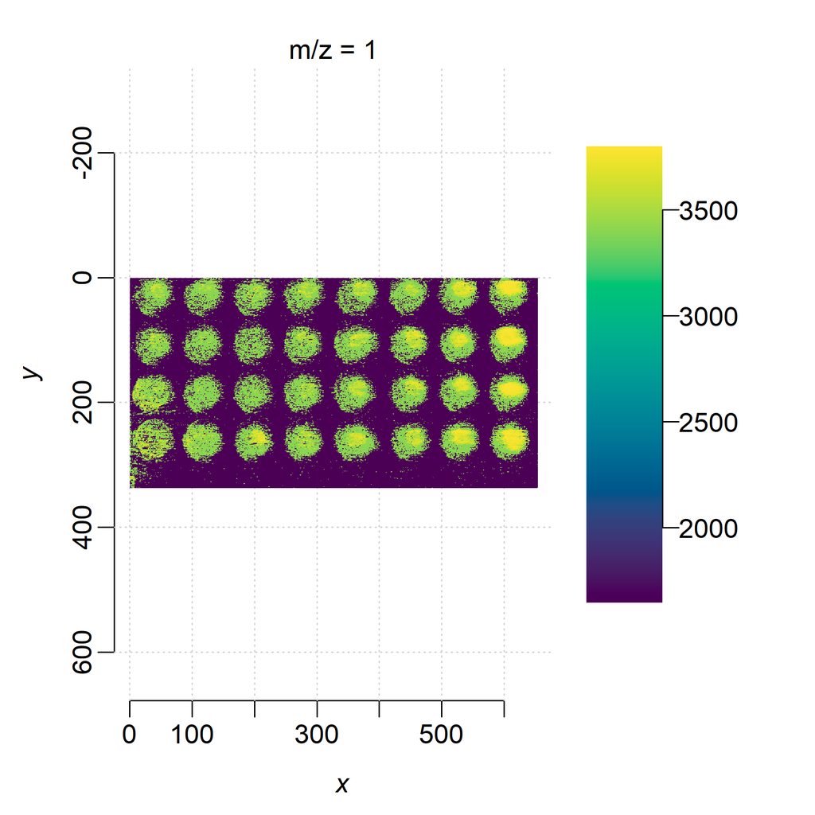

```r
# Image cal mix
image(cal_mix, enhance= "histogram")
```

```r
# Example
#cal1_rep1 <- selectROI(cal_mix, contrast.enhance="suppression")
```

## 4.2 Update pixel metadata

The ROIs for this vignette are taken from `cal_roi_df` (read from .csv file), generated from selecting ROIs with Cardinal::selectROI() and combining for all calibration spots. Additional experimental metadata is taken from `sample_metadata` (read from .csv file).

```r
# Check ROI info
DT::datatable( head(cal_roi_df) )
```

|  | X | cal1_rep1 | cal2_rep1 | cal3_rep1 | cal3p5_rep1 | cal4_rep1 | cal4p5_rep1 | cal5_rep1 | cal1_rep2 | cal2_rep2 | cal3_rep2 | cal3p5_rep2 | cal4_rep2 | cal4p5_rep2 | cal5_rep2 | cal1_rep3 | cal2_rep3 | cal3_rep3 | cal3p5_rep3 | cal4_rep3 | cal4p5_rep3 | cal5_rep3 |
| --- | --- | --- | --- | --- | --- | --- | --- | --- | --- | --- | --- | --- | --- | --- | --- | --- | --- | --- | --- | --- | --- | --- |
| 1 | 1 | False | False | False | False | False | False | False | False | False | False | False | False | False | False | False | False | False | False | False | False | False |
| 2 | 2 | False | False | False | False | False | False | False | False | False | False | False | False | False | False | False | False | False | False | False | False | False |
| 3 | 3 | False | False | False | False | False | False | False | False | False | False | False | False | False | False | False | False | False | False | False | False | False |
| 4 | 4 | False | False | False | False | False | False | False | False | False | False | False | False | False | False | False | False | False | False | False | False | False |
| 5 | 5 | False | False | False | False | False | False | False | False | False | False | False | False | False | False | False | False | False | False | False | False | False |
| 6 | 6 | False | False | False | False | False | False | False | False | False | False | False | False | False | False | False | False | False | False | False | False | False |

```r
cal_level = makeFactor(L1_r1_lipid01 = cal_roi_df$cal1_rep1, L2_r1_lipid01 = cal_roi_df$cal2_rep1,
                       L3_r1_lipid01 = cal_roi_df$cal3_rep1, L4_r1_lipid01 = cal_roi_df$cal3p5_rep1,
                       L5_r1_lipid01 = cal_roi_df$cal4_rep1, L6_r1_lipid01 = cal_roi_df$cal4p5_rep1,
                       L7_r1_lipid01 = cal_roi_df$cal5_rep1,
                       L1_r2_lipid01 = cal_roi_df$cal1_rep2, L2_r2_lipid01 = cal_roi_df$cal2_rep2,
                       L3_r2_lipid01 = cal_roi_df$cal3_rep2, L4_r2_lipid01 = cal_roi_df$cal3p5_rep2,
                       L5_r2_lipid01 = cal_roi_df$cal4_rep2, L6_r2_lipid01 = cal_roi_df$cal4p5_rep2,
                       L7_r2_lipid01 = cal_roi_df$cal5_rep2,
                       L1_r3_lipid01 = cal_roi_df$cal1_rep3, L2_r3_lipid01 = cal_roi_df$cal2_rep3,
                       L3_r3_lipid01 = cal_roi_df$cal3_rep3, L4_r3_lipid01 = cal_roi_df$cal3p5_rep3,
                       L5_r3_lipid01 = cal_roi_df$cal4_rep3, L6_r3_lipid01 = cal_roi_df$cal4p5_rep3,
                       L7_r3_lipid01 = cal_roi_df$cal5_rep3)

#Subset metadata file for calibration DESI-MRM info
sample_metadata_subset = subset(sample_metadata, Sample == cal_fn)

## Update pixel metadata
pData(cal_mix)$sample_type = sample_metadata_subset$Sample_type
pData(cal_mix)$replicate = sample_metadata_subset$Replicate
pData(cal_mix)$identifier = cal_level # match identifier header in cal_metadata
pData(cal_mix)$treatment = sample_metadata_subset$Treatment
pData(cal_mix)$ROI = sapply(as.character(cal_level), FUN = function(x) strsplit(x, "_r")[[1]][1])
pData(cal_mix)$sample_ID = sample_metadata_subset$Sample_ID
pData(cal_mix)$pixel_size = as.numeric(experimentData(cal_mix)$pixelSize)
```

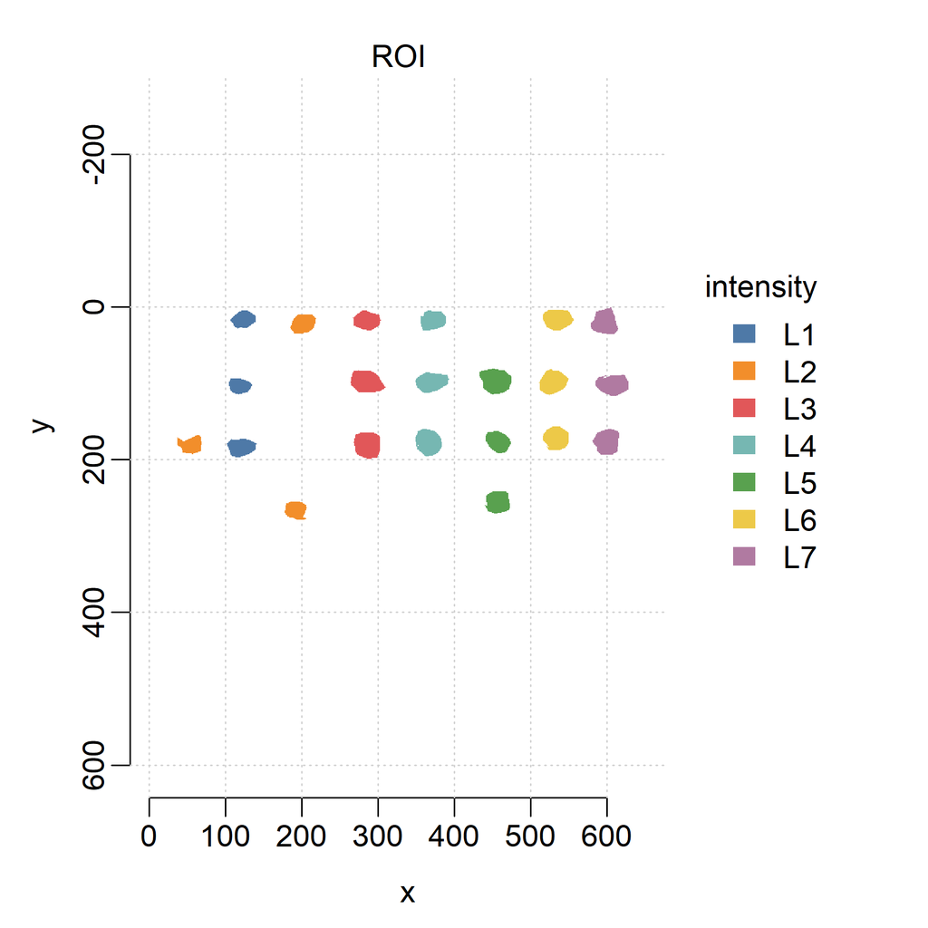

```r
# Image cal mix labelled
image(cal_mix, "ROI", zlab = "intensity")
```

```r
# View updated pixel metadata
DT::datatable(head(data.frame(pData(cal_mix))), width = '90%')
```

|  | x | y | run | sample_type | replicate | identifier | treatment | ROI | sample_ID | pixel_size |
| --- | --- | --- | --- | --- | --- | --- | --- | --- | --- | --- |
| 1 | 1 | 1 | cal_MRM_data | Cal | 1 |  | none |  | omnislide_cal | 50 |
| 2 | 2 | 1 | cal_MRM_data | Cal | 1 |  | none |  | omnislide_cal | 50 |
| 3 | 3 | 1 | cal_MRM_data | Cal | 1 |  | none |  | omnislide_cal | 50 |
| 4 | 4 | 1 | cal_MRM_data | Cal | 1 |  | none |  | omnislide_cal | 50 |
| 5 | 5 | 1 | cal_MRM_data | Cal | 1 |  | none |  | omnislide_cal | 50 |
| 6 | 6 | 1 | cal_MRM_data | Cal | 1 |  | none |  | omnislide_cal | 50 |

## 4.3 Save update calibration DESI-MRM data

Write the new object to imzML (a common open source format for MSI data) for long term storage.

```r
# Save cal_mix imzML for long term storage
cal_imzfile <- tempfile(fileext="_cal.imzML")
writeMSIData(cal_mix, file = cal_imzfile)
list.files(cal_imzfile)
```

```
## [1] "file146c15e93a0b_cal.fdata" "file146c15e93a0b_cal.ibd"
## [3] "file146c15e93a0b_cal.imzML" "file146c15e93a0b_cal.pdata"
```

```r
# Read imzML if needed
#cal_mix = readMSIData(cal_imzfile)
```

# 5. Annotate tissue DESI-MRM pixels

Select ROI around the tissue of interest from the MSI dataset, select background pixels to calculate signal:noise from and annotate pixels based on anatomical features (parenchyma and airways).

## 5.1 Select tissue and background ROIs

Select pixel and background ROIs from `tissue_pixels_df` (read from .csv file), generated from selecting ROIs with Cardinal::selectROI() (as shown previously).

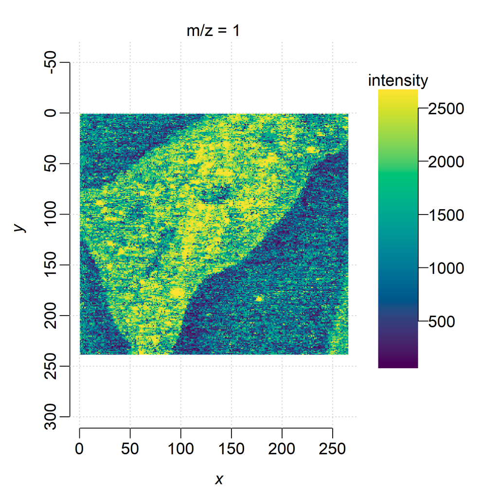

```r
## Image tissue
image(tissue, enhance= "histogram", zlab = "intensity")

tissue_pixels = tissue_pixels_df$tissue_pixels
noise_pixels = tissue_pixels_df$noise_pixels

noise = tissue[, noise_pixels]
tissue = tissue[, tissue_pixels]
```

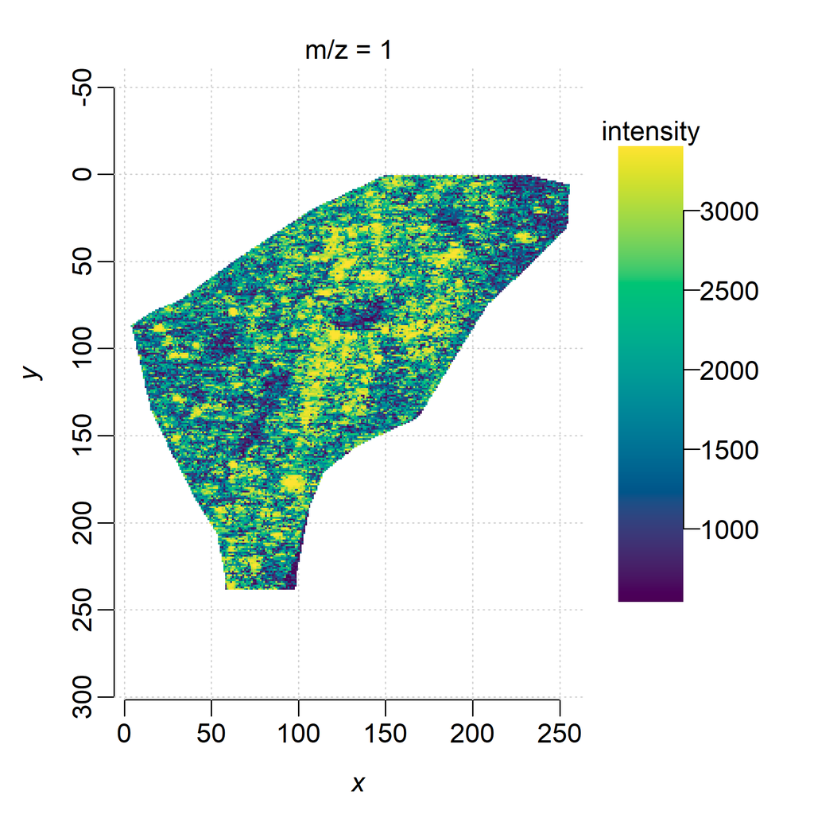

```r
# Image tissue subset
image(tissue, enhance= "histogram", zlab = "intensity")
```

## 5.2 Annotate anatomical features in tissue DESI-MRM

```r
tissue_rois = makeFactor(airway_01 = tissue_anat_ROIs$airway_01,
                         airway_02 = tissue_anat_ROIs$airway_02,
                         airway_03 = tissue_anat_ROIs$airway_03,
                         airway_04 = tissue_anat_ROIs$airway_04,
                         airway_05 = tissue_anat_ROIs$airway_05,
                         airway_06 = tissue_anat_ROIs$airway_06,
                         parenchyma_01 = tissue_anat_ROIs$parenchyma_01,
                         parenchyma_02 = tissue_anat_ROIs$parenchyma_02,
                         parenchyma_03 = tissue_anat_ROIs$parenchyma_03,
                         parenchyma_04 = tissue_anat_ROIs$parenchyma_04,
                         parenchyma_05 = tissue_anat_ROIs$parenchyma_05,
                         parenchyma_06 = tissue_anat_ROIs$parenchyma_06)
```

## 5.3 Update pixel metadata

Additional experimental metadata is taken from `sample_metadata` (read from .csv file).

### 5.3.1 Tissue pixel metadata

```r
#Subset metadata file for tissue DESI-MRM info
sample_metadata_subset = subset(sample_metadata, Sample == tissue_fn)

## Update pixel metadata
pData(tissue)$sample_type = sample_metadata_subset$Sample_type
pData(tissue)$replicate = sample_metadata_subset$Replicate
pData(tissue)$identifier = tissue_rois
pData(tissue)$treatment = sample_metadata_subset$Treatment
pData(tissue)$ROI = sapply(as.character(tissue_rois), FUN = function(x) strsplit(x, "_")[[1]][1])
pData(tissue)$sample_ID = sample_metadata_subset$Sample_ID
pData(tissue)$pixel_size = as.numeric(experimentData(tissue)$pixelSize)
```

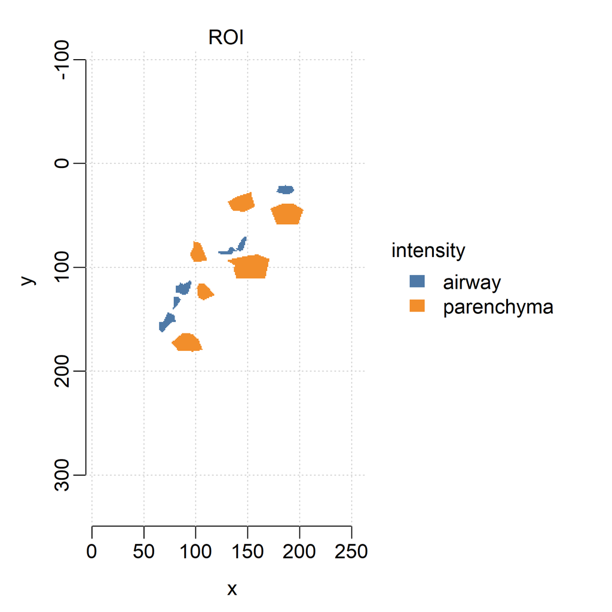

```r
# Image cal mix labelled
image(tissue, "ROI", zlab = "intensity")
```

```r
# View updated pixel metadata
DT::datatable(head(data.frame(pData(tissue))))
```

|  | x | y | run | sample_type | replicate | identifier | treatment | ROI | sample_ID | pixel_size |
| --- | --- | --- | --- | --- | --- | --- | --- | --- | --- | --- |
| 1 | 149 | 1 | tissue_MRM_data | Tissue | 1 |  | HDM |  | GP_1_T1_Ctrl | 50 |
| 2 | 150 | 1 | tissue_MRM_data | Tissue | 1 |  | HDM |  | GP_1_T1_Ctrl | 50 |
| 3 | 151 | 1 | tissue_MRM_data | Tissue | 1 |  | HDM |  | GP_1_T1_Ctrl | 50 |
| 4 | 152 | 1 | tissue_MRM_data | Tissue | 1 |  | HDM |  | GP_1_T1_Ctrl | 50 |
| 5 | 153 | 1 | tissue_MRM_data | Tissue | 1 |  | HDM |  | GP_1_T1_Ctrl | 50 |
| 6 | 154 | 1 | tissue_MRM_data | Tissue | 1 |  | HDM |  | GP_1_T1_Ctrl | 50 |

### 5.3.2 Noise pixel metadata

```r
sample_metadata_subset = subset(sample_metadata, Sample == tissue_fn)

pData(noise)$sample_type = "Noise"
pData(noise)$replicate = sample_metadata_subset$Replicate
pData(noise)$identifier = "noise"
pData(noise)$treatment = sample_metadata_subset$Treatment
pData(noise)$ROI = "noise"
pData(noise)$sample_ID = sample_metadata_subset$Sample_ID
pData(noise)$pixel_size = as.numeric(experimentData(noise)$pixelSize)
```

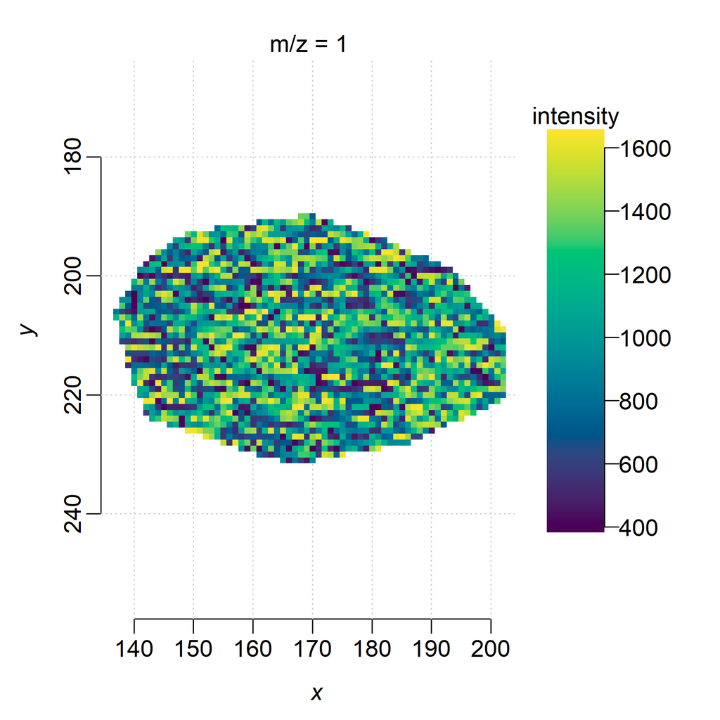

```r
# Image tissue labelled
image(noise, enhance= "histogram", zlab = "intensity")
```

```r
# View updated pixel metadata
DT::datatable(head(data.frame(pData(noise))))
```

|  | x | y | run | sample_type | replicate | identifier | treatment | ROI | sample_ID | pixel_size |
| --- | --- | --- | --- | --- | --- | --- | --- | --- | --- | --- |
| 1 | 168 | 190 | tissue_MRM_data | Noise | 1 | noise | HDM | noise | GP_1_T1_Ctrl | 50 |
| 2 | 169 | 190 | tissue_MRM_data | Noise | 1 | noise | HDM | noise | GP_1_T1_Ctrl | 50 |
| 3 | 170 | 190 | tissue_MRM_data | Noise | 1 | noise | HDM | noise | GP_1_T1_Ctrl | 50 |
| 4 | 161 | 191 | tissue_MRM_data | Noise | 1 | noise | HDM | noise | GP_1_T1_Ctrl | 50 |
| 5 | 162 | 191 | tissue_MRM_data | Noise | 1 | noise | HDM | noise | GP_1_T1_Ctrl | 50 |
| 6 | 163 | 191 | tissue_MRM_data | Noise | 1 | noise | HDM | noise | GP_1_T1_Ctrl | 50 |

Write the new object to imzML (a common open source format for MSI data) for long term storage.

```r
# Save tissue imzML for long term storage
writeMSIData(tissue, file = sprintf("%s/%s.raw/tissue.imzML", data_path, tissue_fn))
#tissue = readMSIData(file = sprintf("%s/%s.raw/tissue.imzML", data_path, tissue_fn))

# Save noise imzML for long term storage
writeMSIData(noise, file = sprintf("%s/%s.raw/noise.imzML", data_path, tissue_fn))
#noise = readMSIData(file = sprintf("%s/%s.raw/noise.imzML", data_path, tissue_fn))
```

# 6. Process calibration and tissue DESI-MRM data

Process the DESI-MRM data by: * Setting 0 values in DESI-MRM data to NA * Removing MRM channels with no data * Normalise the intensity of each feature at each pixel to the internal standard intensity (if present) * Calculate signal:noise ratio (SNR) for each feature at each pixel

## 6.1 Merge calibration and tissue data

Combine all calibration and tissue MSI datasets into a single study dataset (MRM channels and pixel metadata headers must match).

```r
msi_combined = combine_MSIs(cal_mix, tissue, noise)
msi_combined
```

```
## quant_MSImagingExperiment with 1 features and 252954 spectra
## spectraData(1): intensity
## featureData(5): mz, analyte, precursor_mz, product_mz, name
## pixelData(10): x, y, run, ..., ROI, sample_ID, pixel_size
## coord(2): x = 1...654, y = 1...337
## runNames(2): cal_MRM_data, tissue_MRM_data
## experimentData(1): pixelSize
## mass range: 1 to 1
## centroided: NA
```

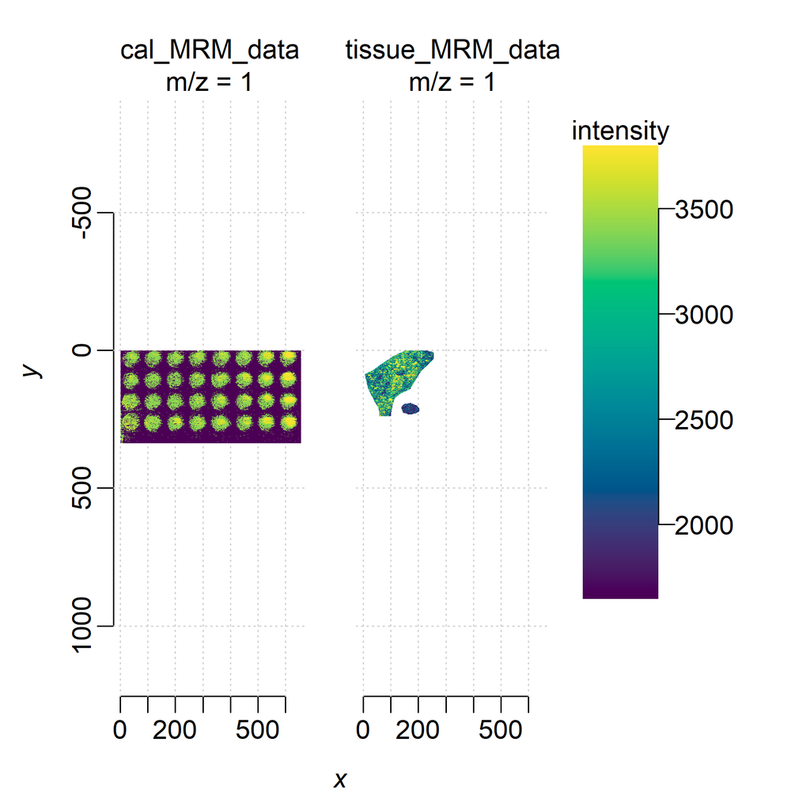

```r
image(msi_combined, enhance= "histogram", zlab = "intensity")

# Save combined imzML for long term storage
writeMSIData(msi_combined, file = sprintf("%s/%s.raw/combined.imzML", data_path, tissue_fn))
#tissue = readMSIData(file = sprintf("%s/%s.raw/combined.imzML", data_path, tissue_fn))
```

## 6.2 Set 0 values to NA

```r
msi_combined = zero2na(MSIobject = msi_combined, val_slot = "intensity")
msi_combined
```

```
## quant_MSImagingExperiment with 1 features and 252954 spectra
## spectraData(1): intensity
## featureData(5): mz, analyte, precursor_mz, product_mz, name
## pixelData(10): x, y, run, ..., ROI, sample_ID, pixel_size
## coord(2): x = 1...654, y = 1...337
## runNames(2): cal_MRM_data, tissue_MRM_data
## experimentData(1): pixelSize
## mass range: 1 to 1
## centroided: NA
```

```r
#image(msi_combined, enhance= "histogram", zlab = "intensity")
```

## 6.3 Remove MRM chanels with no data

```r
msi_combined = remove_blank_mzs(MSIobject = msi_combined)
msi_combined
```

```
## quant_MSImagingExperiment with 1 features and 252954 spectra
## spectraData(1): intensity
## featureData(5): mz, analyte, precursor_mz, product_mz, name
## pixelData(10): x, y, run, ..., ROI, sample_ID, pixel_size
## coord(2): x = 1...654, y = 1...337
## runNames(2): cal_MRM_data, tissue_MRM_data
## experimentData(1): pixelSize
## mass range: 1 to 1
## centroided: NA
```

```r
#image(msi_combined, enhance= "histogram", zlab = "intensity")
```

## 6.4 Normalise intensity value to IS (if present)

Normalise each ion intensity to the intensity of the IS (if present), to account for variance in the instrument performance and extraction of analytes form the surface (the latter depending on how the IS is introduced). in this experiment no IS used to no change… creates a bew spectraData channel though

```r
msi_combined = int2response(MSIobject = msi_combined, val_slot = "intensity")
```

```
## [1] "No IS in this study so normalisation skipped"
```

```r
msi_combined
```

```
## quant_MSImagingExperiment with 1 features and 252954 spectra
## spectraData(2): intensity, response
## featureData(5): mz, analyte, precursor_mz, product_mz, name
## pixelData(10): x, y, run, ..., ROI, sample_ID, pixel_size
## coord(2): x = 1...654, y = 1...337
## runNames(2): cal_MRM_data, tissue_MRM_data
## experimentData(1): pixelSize
## mass range: 1 to 1
## centroided: NA
```

```r
#image(msi_combined, response ~ x * y, enhance= "histogram", zlab = "response")
```

## 6.5 Calculate signal:noise ratio (SNR)

```r
msi_combined = int2snr(MSIobject = msi_combined, val_slot = "response",
                       noise = "Noise", tissue = "Tissue", snr_thresh = 3)
msi_combined
```

```
## quant_MSImagingExperiment with 1 features and 252954 spectra
## spectraData(3): intensity, response, snr
## featureData(5): mz, analyte, precursor_mz, product_mz, name
## pixelData(10): x, y, run, ..., ROI, sample_ID, pixel_size
## coord(2): x = 1...654, y = 1...337
## runNames(2): cal_MRM_data, tissue_MRM_data
## experimentData(1): pixelSize
## mass range: 1 to 1
## centroided: NA
```

```r
#image(msi_combined, snr ~ x * y, enhance= "histogram", zlab = "snr")
```

# 7. Estimated quantification

Determine the concentration (pg/pixel or pg/mm2) at the surface of the tissue samples, based on the calibration data.

## 7.1 Average the response (response/pixel) for each calibration spot

Calculate the mean response or intensity per pixel for the ROI at each calibration level across all calibration replicates.

```r
msi_combined = summarise_cal_levels(MSIobject = msi_combined,
                                    cal_metadata = cal_metadata,
                                    val_slot = "response",
                                    cal_label = "Cal",
                                    id = "identifier")

# Number of pixels per calibration spot
DT::datatable(data.frame(msi_combined@calibrationInfo@cal_response_data))
```

|  | cal_spot | response_perpixel | pixels | level | lipid | amount_pg | pg_perpixel |
| --- | --- | --- | --- | --- | --- | --- | --- |
| 1 | L7_r1_lipid01 | 38000.5618729097 | 897 | L7 | 12_13-DiHOME | 100 | 0.1114827201783724 |
| 2 | L6_r1_lipid01 | 13610.00821596244 | 852 | L6 | 12_13-DiHOME | 20 | 0.02347417840375587 |
| 3 | L1_r1_lipid01 | 5229.391382405745 | 557 | L1 | 12_13-DiHOME | 0.2 | 0.0003590664272890485 |
| 4 | L3_r1_lipid01 | 6200.397988505747 | 696 | L3 | 12_13-DiHOME | 2 | 0.002873563218390805 |
| 5 | L4_r1_lipid01 | 7758.274031563845 | 697 | L4 | 12_13-DiHOME | 5 | 0.007173601147776184 |
| 6 | L2_r1_lipid01 | 5172.832831325301 | 664 | L2 | 12_13-DiHOME | 1 | 0.001506024096385542 |
| 7 | L5_r2_lipid01 | 9347.259328358208 | 1072 | L5 | 12_13-DiHOME | 10 | 0.009328358208955223 |
| 8 | L6_r2_lipid01 | 12414.18262806236 | 898 | L6 | 12_13-DiHOME | 20 | 0.022271714922049 |
| 9 | L3_r2_lipid01 | 4931.780099502487 | 1005 | L3 | 12_13-DiHOME | 2 | 0.001990049751243781 |
| 10 | L4_r2_lipid01 | 7237.720554272517 | 866 | L4 | 12_13-DiHOME | 5 | 0.005773672055427252 |

[output cut: 11 more lines]

## 7.2 Generate calibration curves

```r
msi_combined = create_cal_curve(MSIobject = msi_combined,
                                cal_type = "Cal")
```

## 7.3 Check calibration curves

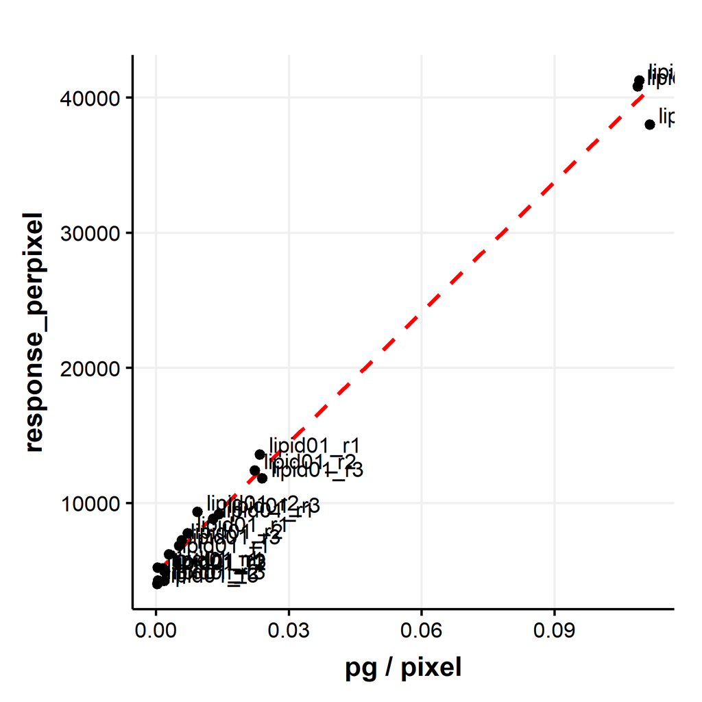

```r
# Plot linear model
d = msi_combined@calibrationInfo@cal_response_data %>%
  mutate(labs = sapply(cal_spot, FUN=function(x){
    return( paste(strsplit(x, "_")[[1]][3:2], collapse="_") )})) %>%
  subset(!labs %in% c("L7_rep1", "L7_rep2"))

p = ggplot(d, aes(x=pg_perpixel, y = response_perpixel, label =labs)) +
  geom_smooth(method='lm', formula= y~x, col = "red", se=F, size = 1, linetype = "dashed") +
  geom_point(size = 2) +
  theme_Publication() +
  geom_text(hjust=-0.1, vjust=-0.1) +
  labs(x = "pg / pixel")
p
```

```r
# linear model equation
msi_combined@calibrationInfo@cal_list
```

```
## $`12_13-DiHOME`
##
## Call:
## lm(formula = response_perpixel ~ pg_perpixel, data = cal_subset,
##     weights = (1/pg_perpixel), na.action = na.exclude)
##
## Coefficients:
## (Intercept)  pg_perpixel
##        4414       339782
```

```r
# r2 values for each calibration
DT::datatable(data.frame(msi_combined@calibrationInfo@r2_df))
```

|  | feature | r2 |
| --- | --- | --- |
| 1 | 12_13-DiHOME | 0.9266692815910228 |

## 7.4 Quantify analyte concentrations at tissue surface

```r
msi_combined = int2conc(MSIobject = msi_combined,
                        val_slot = "response",
                        pixels = c("Tissue", "Noise"))
```

```r
# Save the combined DESI-MRM object as RDS - enables multiple spectra data channels to be stored in single object
rdsfile <- tempfile(fileext=".RDS")

saveRDS(msi_combined, file = sprintf("%s/%s.raw/combined_data.RDS", data_path, tissue_fn))

list.files(cal_imzfile)
```

```
## [1] "file146c15e93a0b_cal.fdata" "file146c15e93a0b_cal.ibd"
## [3] "file146c15e93a0b_cal.imzML" "file146c15e93a0b_cal.pdata"
```

```r
#readRDS(sprintf("%s/%s.raw/combined_data.RDS", data_path, tissue_fn))
```

# 8. Image and save the different spectral data (tissue only)

Generate ion images for each data type: * intensity * Response (normalised analyte intensity to internal standard) * signal-to-noise ratio (SNR) * COncentration in ‘pg /pixel’ and ‘pg / mm2’

Then write each data type to separate imzML for long term storage.

```
## [1] "file146c3f7934aa_tissue_intensity.fdata"
## [2] "file146c3f7934aa_tissue_intensity.ibd"
## [3] "file146c3f7934aa_tissue_intensity.imzML"
## [4] "file146c3f7934aa_tissue_intensity.pdata"
```

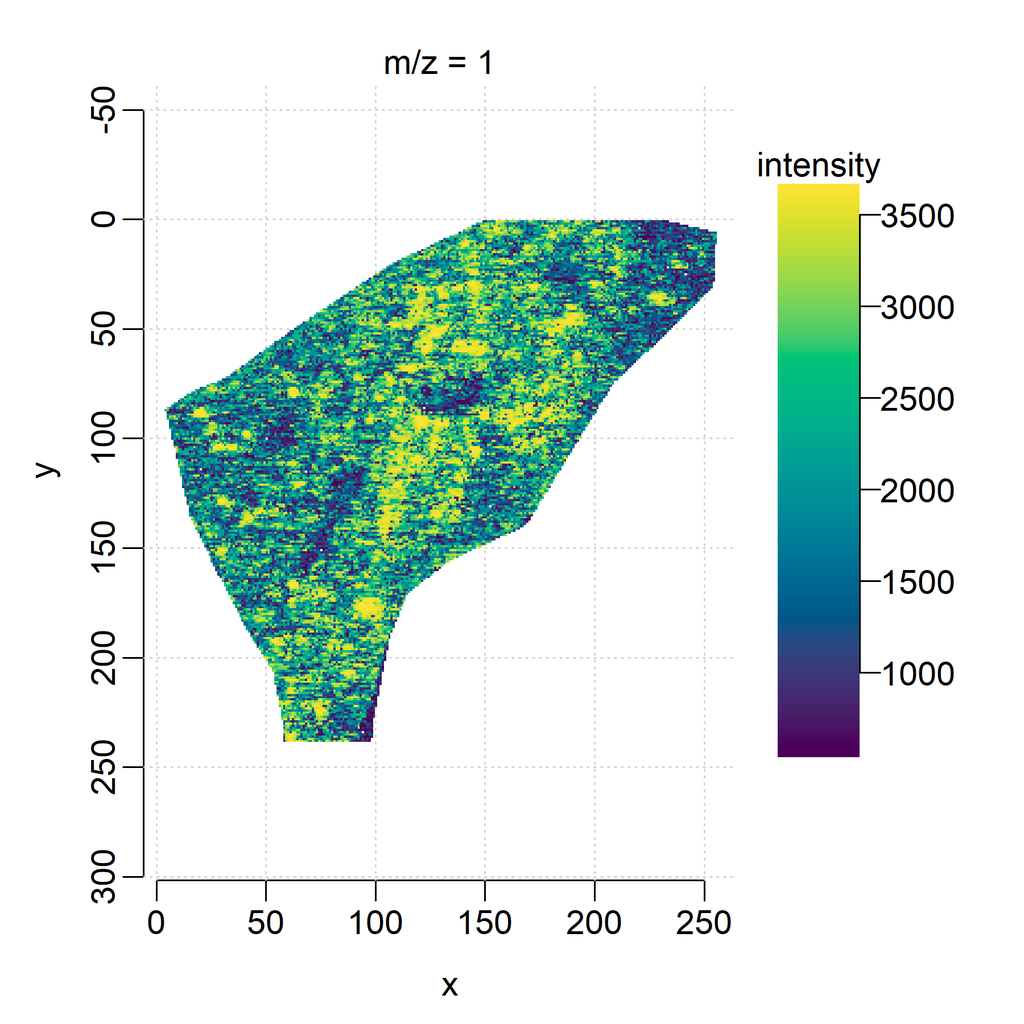

```r
msi_tissue = msi_combined[, which(pData(msi_combined)$sample_type == "Tissue")]

# image intensity of 12,13-DiHOME across tissue
image(msi_tissue, intensity ~ x * y, enhance= "histogram", zlab = "intensity")

# Save imzML for long term storage
imzfile <- tempfile(fileext="_tissue_intensity.imzML")
writeMSIData(msi_tissue, intensity=spectra(msi_tissue, "intensity"), file = imzfile)
list.files(imzfile)
```

```
## [1] "file146c27841a88_tissue_response.fdata"
## [2] "file146c27841a88_tissue_response.ibd"
## [3] "file146c27841a88_tissue_response.imzML"
## [4] "file146c27841a88_tissue_response.pdata"
```

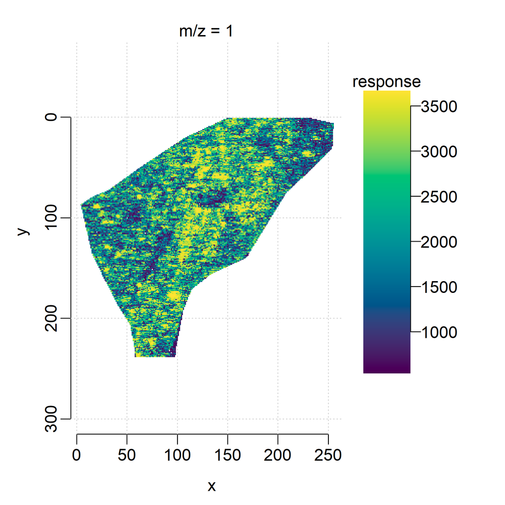

```r
# image response of 12,13-DiHOME across tissue
image(msi_tissue, response ~ x * y, enhance= "histogram", zlab = "response")

# Save imzML for long term storage
imzfile <- tempfile(fileext="_tissue_response.imzML")
writeMSIData(msi_tissue, intensity=spectra(msi_tissue, "response"), file = imzfile)
list.files(imzfile)
```

Recall from `int2snr` a SNR threshold of 3 was used.

```
## [1] "file146c5ab11ff2_tissue_snr.fdata" "file146c5ab11ff2_tissue_snr.ibd"
## [3] "file146c5ab11ff2_tissue_snr.imzML" "file146c5ab11ff2_tissue_snr.pdata"
```

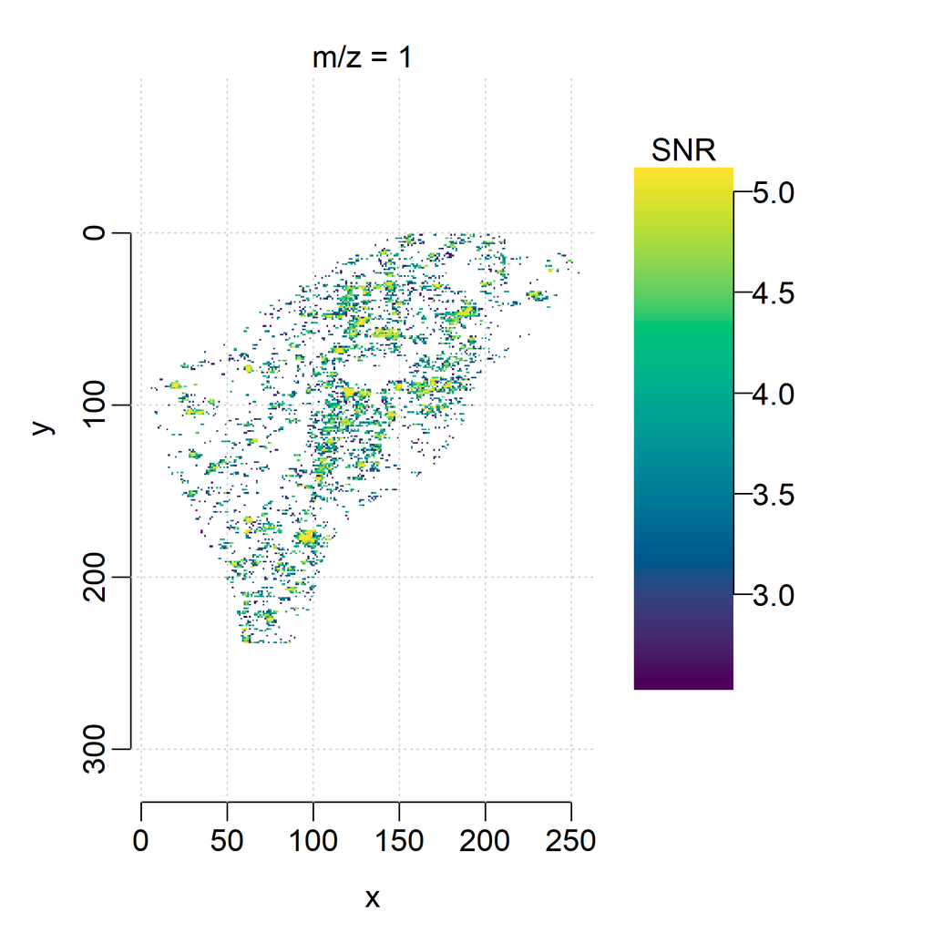

```r
# image signla-noise-ratio of 12,13-DiHOME across tissue
image(msi_tissue, snr ~ x * y, enhance= "histogram", zlab = "SNR")

# Save imzML for long term storage
imzfile <- tempfile(fileext="_tissue_snr.imzML")
writeMSIData(msi_tissue, intensity=spectra(msi_tissue, "snr"), file = imzfile)
list.files(imzfile)
```

For concentration a SNR > 5 is applied.

```
## [1] "file146c45ce19cd_tissue__pg_pixel.fdata"
## [2] "file146c45ce19cd_tissue__pg_pixel.ibd"
## [3] "file146c45ce19cd_tissue__pg_pixel.imzML"
## [4] "file146c45ce19cd_tissue__pg_pixel.pdata"
```

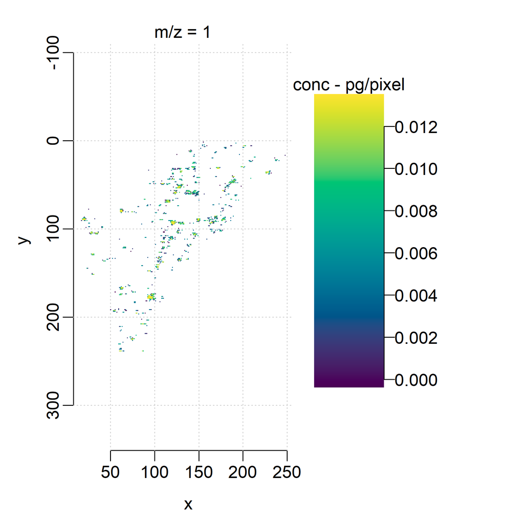

```r
msi_tissue_conc = msi_tissue[, which(spectra(msi_combined,"snr")[1,] >= 5)]

# image conc (pg/pixel) of 12,13-DiHOME across tissue
image(msi_tissue_conc, `conc - pg/pixel` ~ x * y, enhance= "histogram", zlab = "conc - pg/pixel")

# Save imzML for long term storage
imzfile <- tempfile(fileext="_tissue__pg_pixel.imzML")
writeMSIData(msi_tissue, intensity=spectra(msi_tissue, "conc - pg/pixel"), file = imzfile)
list.files(imzfile)
```

```
## [1] "file146c50787592_tissue_pg_mm2.fdata"
## [2] "file146c50787592_tissue_pg_mm2.ibd"
## [3] "file146c50787592_tissue_pg_mm2.imzML"
## [4] "file146c50787592_tissue_pg_mm2.pdata"
```

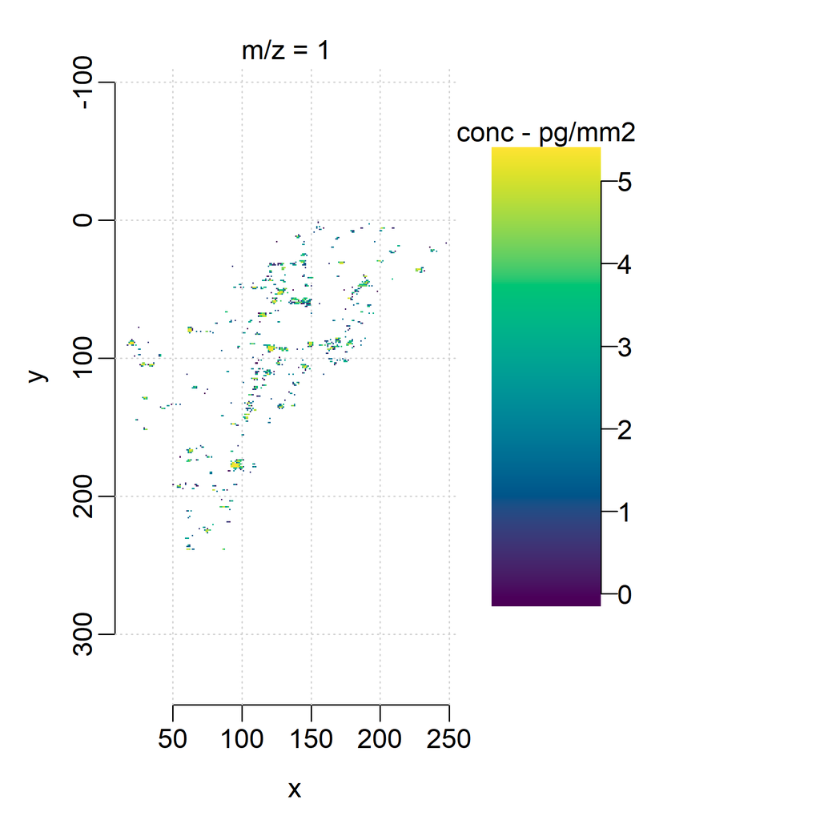

```r
# image conc (pg/pixel) of 12,13-DiHOME across tissue
image(msi_tissue_conc, `conc - pg/mm2` ~ x * y, enhance= "histogram", zlab = "conc - pg/mm2")

# Save imzML for long term storage
imzfile <- tempfile(fileext="_tissue_pg_mm2.imzML")
writeMSIData(msi_tissue, intensity=spectra(msi_tissue, "conc - pg/mm2"), file = imzfile)
list.files(imzfile)
```

quantMSImageR also provides an imaging functionality based on the ggplot2 package. Please see manual for more infomation on how to use this.

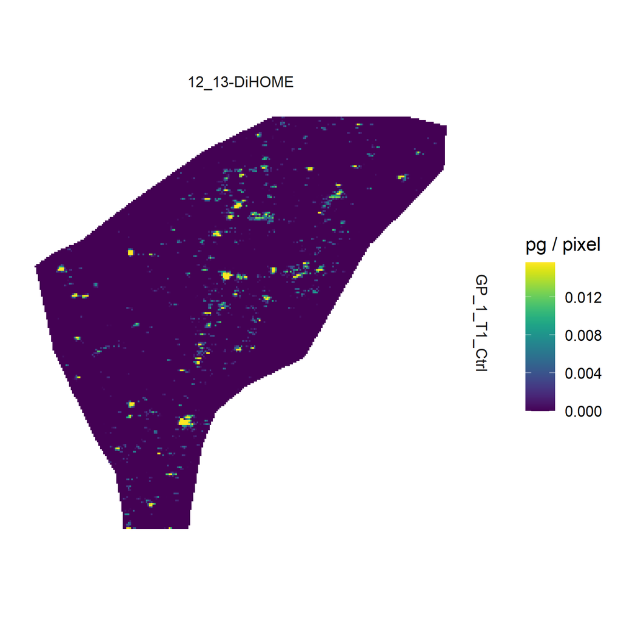

```r
imageR(msi_tissue,
           val_slot = "conc - pg/pixel",
           value = "pg / pixel",
           scale = "suppress", # "suppress" "histogram"
           threshold = 5,
           sample_lab = "sample_ID",
           pixels = "Tissue",
           percentile=99.5,
           overlay = F,
           feat_ind = 1,
           blank_back = F)
```

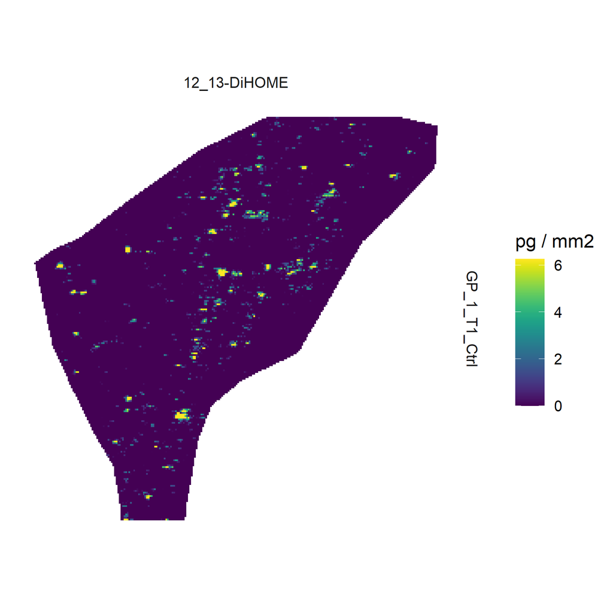

```r
imageR(msi_tissue,
           val_slot = "conc - pg/mm2",
           value = "pg / mm2",
           scale = "suppress", # "suppress" "histogram"
           threshold = 5,
           sample_lab = "sample_ID",
           pixels = "Tissue",
           percentile=99.5,
           overlay = F,
           feat_ind = 1,
           blank_back = F)
```

The MSIobject containing all the above datatypes for the DESI-MRM experiment can be stored as RDS. However this is less stable than imzML format.

```r
# Save cal_mix imzML for long term storage
rdsfile <- tempfile(fileext=".RDS")

saveRDS(msi_combined, file = sprintf("%s/%s.raw/combined_data.RDS", data_path, tissue_fn))

list.files(cal_imzfile)
```

```
## [1] "file146c15e93a0b_cal.fdata" "file146c15e93a0b_cal.ibd"
## [3] "file146c15e93a0b_cal.imzML" "file146c15e93a0b_cal.pdata"
```

```r
# Read RDS if needed
#readRDS(sprintf("%s/%s.raw/combined_data.RDS", data_path, tissue_fn))
```

# 9. Statistical analysis

Statistical analyses will be study dependent, however to make the data compatible with more standard omics approaches a matrix (rows = m/z, cols = ROI label) can be output with the associated metadata about each ROI.

The examples here lack statistical power and feature space for MVA, but show how these tools work for larger MSI datasets.

## 9.1 Extract average concentration, response or signal-noise-ratio information

```r
# Extract the average amount per pixel at each ROI in tissue (stored in the S4 object)
msi_tissue <- createMSIDatamatrix(MSIobject = msi_tissue, val_slot = "response", roi_header = "identifier")

# Data matrix with average concentration over ROI for each lipid
roi_average_matrix = msi_tissue@tissueInfo@roi_average_matrix
DT::datatable(roi_average_matrix, width = '50%')
```

|  | 12_13-DiHOME |
| --- | --- |
| airway_01 | 1238.705479452055 |
| airway_02 | 1212.507352941177 |
| airway_03 | 1341.372549019608 |
| airway_04 | 1054.44262295082 |
| airway_05 | 1081.205882352941 |
| airway_06 | 1273.418181818182 |
| parenchyma_01 | 3497.734104046243 |
| parenchyma_02 | 3998.118279569892 |
| parenchyma_03 | 2789.319047619048 |
| parenchyma_04 | 3034.212827988338 |

[output cut: 2 more lines]

```r
# Data matrix with concentration per pixel for entire sample for each lipid
all_pixel_matrix = msi_tissue@tissueInfo@all_pixel_matrix
DT::datatable(head(all_pixel_matrix), width = '50%')
```

|  | 12_13-DiHOME |
| --- | --- |
| pixel_1 | 1447 |
| pixel_2 | 1740 |
| pixel_3 | 888 |
| pixel_4 | 1224 |
| pixel_5 | 1358 |
| pixel_6 | 1470 |

```r
# Data pertaining to sample and pixel (including ROI) metadata
sample_metadata = msi_tissue@tissueInfo@sample_metadata
DT::datatable(head(sample_metadata))
```

|  | pixel_ind | x | y | run | sample_type | replicate | identifier | treatment | ROI | sample_ID | pixel_size |
| --- | --- | --- | --- | --- | --- | --- | --- | --- | --- | --- | --- |
| 1 | pixel_1 | 186 | 21 | tissue_MRM_data | Tissue | 1 | airway_06 | HDM | airway | GP_1_T1_Ctrl | 50 |
| 2 | pixel_2 | 180 | 22 | tissue_MRM_data | Tissue | 1 | airway_06 | HDM | airway | GP_1_T1_Ctrl | 50 |
| 3 | pixel_3 | 181 | 22 | tissue_MRM_data | Tissue | 1 | airway_06 | HDM | airway | GP_1_T1_Ctrl | 50 |
| 4 | pixel_4 | 182 | 22 | tissue_MRM_data | Tissue | 1 | airway_06 | HDM | airway | GP_1_T1_Ctrl | 50 |
| 5 | pixel_5 | 183 | 22 | tissue_MRM_data | Tissue | 1 | airway_06 | HDM | airway | GP_1_T1_Ctrl | 50 |
| 6 | pixel_6 | 184 | 22 | tissue_MRM_data | Tissue | 1 | airway_06 | HDM | airway | GP_1_T1_Ctrl | 50 |

```r
# Data pertaining to feature metadata
feature_metadata = data.frame(fData(msi_tissue))
DT::datatable(feature_metadata, width = '75%')
```

|  | mz | analyte | precursor_mz | product_mz | name |
| --- | --- | --- | --- | --- | --- |
| 1 | 1 | Analyte | 313.2 | 183.1 | 12_13-DiHOME |

## 9.2 Univariate stats

In this example we generate boxplots for the lipid 12,13-DiHOME between different tissue types (parenchyma and airways) as annotated in section 5.2.

First using the average matrix where the mean per ROI (6 ROIs per tissue type across a single tissue) is used:

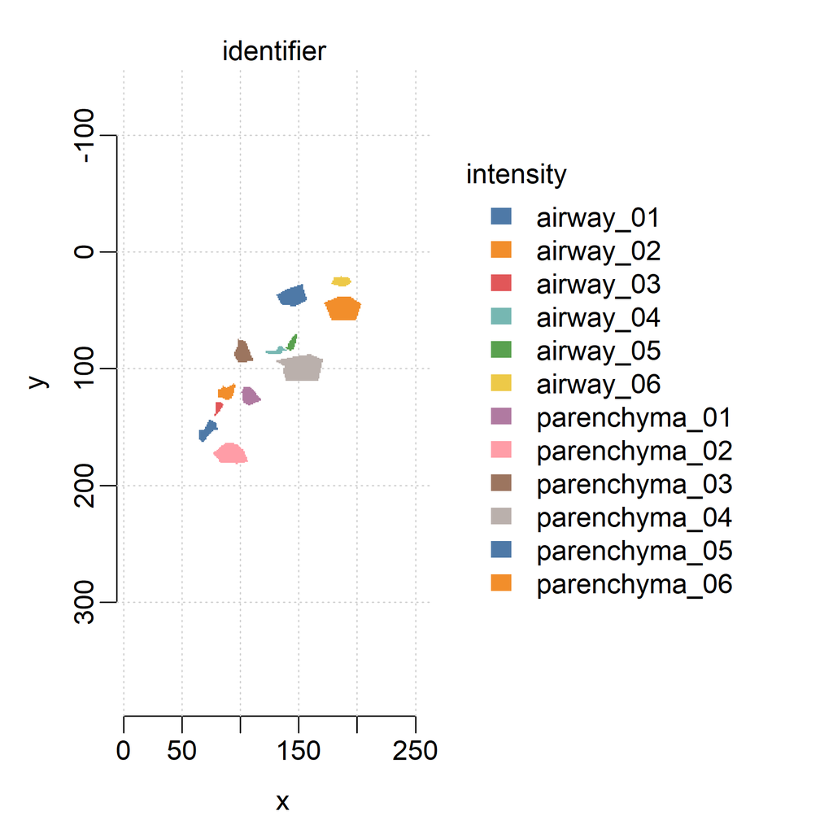

```r
image(tissue, "identifier", zlab = "intensity")

uva_df_ave = roi_average_matrix %>%
  tibble::rownames_to_column("roi_lab") %>%
  tidyr::pivot_longer(cols = -roi_lab, names_to = "lipid", values_to = "int") %>%
  dplyr::left_join(y= distinct(sample_metadata %>% select(any_of(c("identifier", "ROI")))), by = c("roi_lab" = "identifier"), keep=F) %>%
  rename("tissue_type" = "ROI")

p_val_ave = t.test(uva_df_ave$int[uva_df_ave$tissue_type == "airway"], uva_df_ave$int[uva_df_ave$tissue_type == "parenchyma"])[["p.value"]]
```

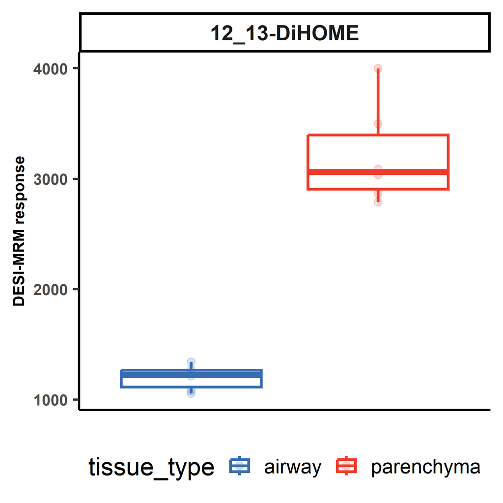

```r
ggplot(uva_df_ave, aes(x=tissue_type, col=tissue_type, y = int)) +
  theme_classic(base_size = 18) +
  scale_colour_Publication() +
  geom_boxplot(alpha = 0.1, size = 1) +
  geom_point(size = 2.5, alpha = 0.2) +
  labs(x="Tissue type", y = "DESI-MRM response") +
  theme(legend.position="bottom",
        axis.text.x = element_blank(), #element_text(size=11, face="bold"),
        axis.text.y = element_text(size=11, face="bold"),
        axis.title.x =  element_blank(),
        axis.ticks.x = element_blank(),
        axis.title.y =  element_text(size=11, face="bold"),
        strip.text = element_text(size=15, face="bold")) +
  facet_wrap(~lipid, scale = "free", nrow=1)
```

This gives a significant difference in 12,13-DiHOME surface abundance between parenchyma and airways with p-val 6.9725908^{-5}.

Also by sampling 300 pixels across all of the annotated parenchyma and airways within the tissue:

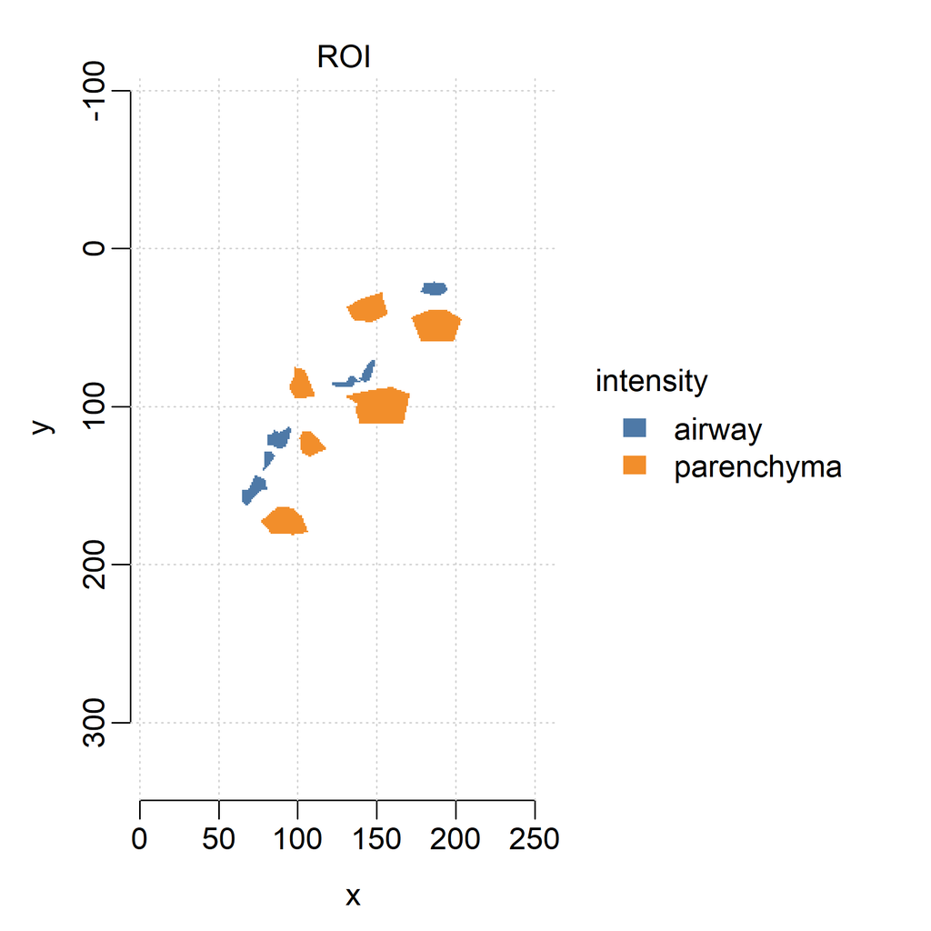

```r
image(tissue, "ROI", zlab = "intensity")

uva_df_all = all_pixel_matrix %>%
  tibble::rownames_to_column("pixel_ind") %>%
  tidyr::pivot_longer(cols = -pixel_ind, names_to = "lipid", values_to = "int") %>%
  dplyr::left_join(y= distinct(sample_metadata %>% select(any_of(c("pixel_ind", "ROI")))), by = "pixel_ind", keep=F) %>%
  rename("tissue_type" = "ROI") %>%
  group_by(tissue_type) %>%
  mutate(num = n()) %>%
  slice_sample(n = 300)

p_val_all = t.test(uva_df_all$int[uva_df_all$tissue_type == "airway"], uva_df_all$int[uva_df_all$tissue_type == "parenchyma"])[["p.value"]]
```

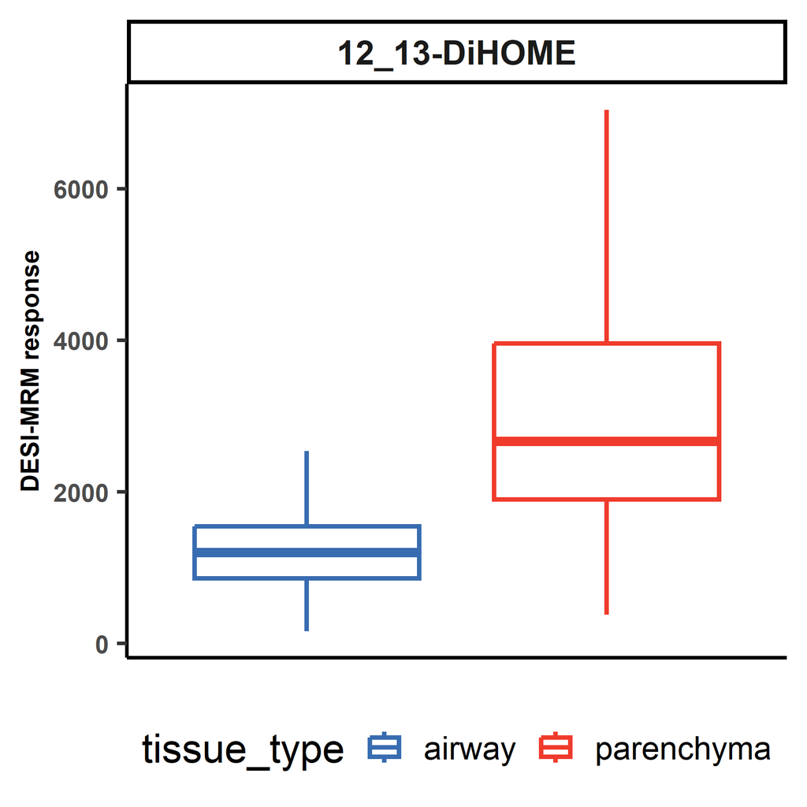

```r
ggplot(uva_df_all, aes(x=tissue_type, col=tissue_type, y = int)) +
  theme_classic(base_size = 18) +
  scale_colour_Publication() +
  geom_boxplot(alpha = 0.1, size = 1, outliers=FALSE) +
  labs(x="Tissue type", y = "DESI-MRM response") +
  theme(legend.position="bottom",
        axis.text.x = element_blank(), #element_text(size=11, face="bold"),
        axis.text.y = element_text(size=11, face="bold"),
        axis.title.x =  element_blank(),
        axis.ticks.x = element_blank(),
        axis.title.y =  element_text(size=11, face="bold"),
        strip.text = element_text(size=15, face="bold")) +
  facet_wrap(~lipid, scale = "free", nrow=1)
```

This gives a significant difference in 12,13-DiHOME surface abundance between parenchyma and airways with p-val 2.3218184^{-29}.